# Bootstrap Analysis in Copepod and Fish Data

Kuei Yueh Ko

2017/3/9

# Set Environment

import required package and set working directory

```r
library(readxl)
# set work space
workdir <- "C:\\Users\\clint\\Documents\\GitHub\\BlogDataAnalysis"
setwd(file.path(workdir, "Analysis"))

# path for data
filePathData <- file.path(
    workdir,
    "Data\\StatCompEcology\\Copepod")
```

# Exploratory Data Analysis (EDA)

Read in the data:

- copepod density (cpodDens)
- fish density (fishDens)

```r
# read in data from excel file
dat <- read_excel(
    file.path(filePathData, "enviANDdensity.xls"),
    sheet=1)
#head(dat)

# get the density of fish and copepod
fishDens <- dat$`FishDensity (ind./1000m3)`
cpodDens <- dat$`CopepodDensity ind./m3)`
#head(fishDens)
#head(cpodDens)
```

### Scatter Plot

Create function to perform linear regression and perform linear regression on fish density and copepod density

```r
RegBeta <- function(x, y){
    # Function RegBeta return the coefficient of
    # linear regression
    # x: independent variable
    # y: dependent variable
    ###################################
    # construct Design matrix
    X <- as.matrix(cbind(1, x))
    # solve by projecting to the solution space
    b <- solve(t(X) %*% X) %*% t(X) %*% y
    # return the parameters
    return(b)
} # end func RegBeta
#################################
# Calculate & Store
# parameters of linear regression
beta <- list()
beta$Val <- RegBeta(x=cpodDens, y=fishDens)
beta$b0  <- beta$Val[1]
beta$b1  <- beta$Val[2]
```

visualize the densities with scatter plot

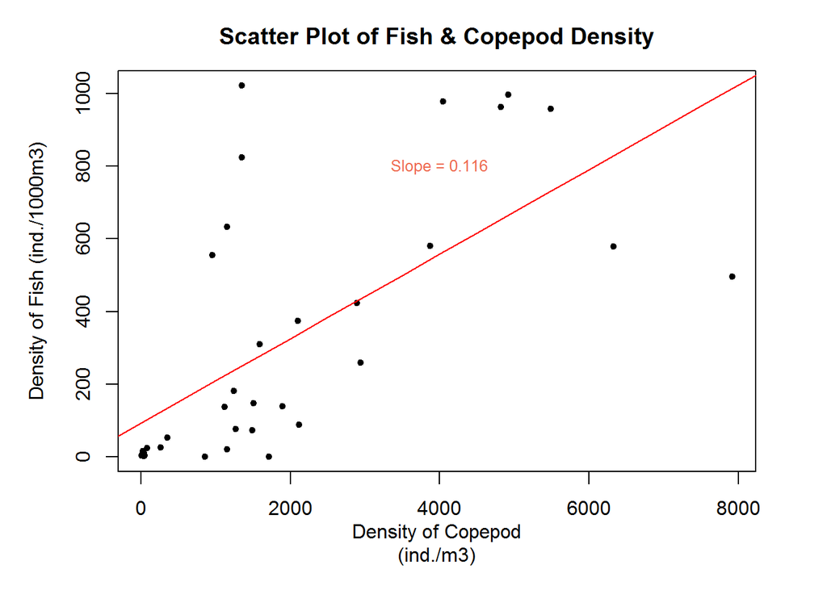

```r
# set margin
par(mar=c(5, 5, 3, 3))

# scatterplot
plot(cpodDens, fishDens,
     pch=20,
     xlab="Density of Copepod\n(ind./m3)",
     ylab="Density of Fish (ind./1000m3)",
     main="Scatter Plot of Fish & Copepod Density")

# regression line
x <- seq(-500, 9000, by=500)
y <- beta$b0 + beta$b1 * x
lines(x, y, col="red") # add regression line

# add text: slope of linear regression line
text(x=4000, y=800,
     cex = .8, col = "#ee6a50",
     paste(
         "Slope =",
         signif(beta$b1, 3)))
```

### Summary Statistics

calculate and store the statistics of densities  
(Mean, Standard deviation, Median, and Standard Error of Mean)

```r
# copepod densities
res <- list()
res$Val    <- cpodDens
res$Mean   <- mean(res$Val)
res$SD     <- sd(res$Val)
res$SE     <- res$SD/length(res$Val)^0.5
res$Median <- median(res$Val)
cpod <- res

# fish densities
res <- list()
res$Val    <- fishDens
res$Mean   <- mean(res$Val)
res$SD     <- sd(res$Val)
res$SE     <- res$SD/length(res$Val)^0.5
res$Median <- median(res$Val)
fish <- res
########################
cat("",
    "Mean of Copepod Density", cpod$Mean, "\n",
    "SE   of Copepod Density", cpod$SE,   "\n",
    "Mean of Fish    Density", fish$Mean, "\n",
    "SE   of Fish    Density", fish$SE)
```

```
##  Mean of Copepod Density 1972.374
##  SE   of Copepod Density 342.5549
##  Mean of Fish    Density 322.4516
##  SE   of Fish    Density 61.23107
```

Helper Function to plot the statistics

```r
# function to plot the deviation
PlotArrows <- function(x1, y1, x2, y2, ...){
    for (idx in seq_along(x1)){
        arrows(x1[idx],y1[idx],
               x2[idx],y2[idx],
               ...)
    } # end for loop
} # end func PlotArrows

# function to plot the summary statistics
PlotStat <- function(MU, SE, ...){
    # plot the figure
    plot(MU, xaxt='n',
         xlab="", ylab="",
         xlim=c(0,length(MU)*1.3),
         ylim=c(min(MU)-max(SE)*1.1,
                max(MU)+max(SE)*1.1),
         ...)

    # add standard error
    PlotArrows(
        seq_along(MU), MU-SE,
        seq_along(MU), MU+SE,
        code=3,
        length=0.1,
        lwd=2,
        angle=90,
        col='red')

    # add mean
    points(seq_along(MU), MU,
        pch=19, cex=1.0,
        bg="black")
} # end func PlotStat
```

compare the **mean** and **standard error of mean** of copepod and fish statistics

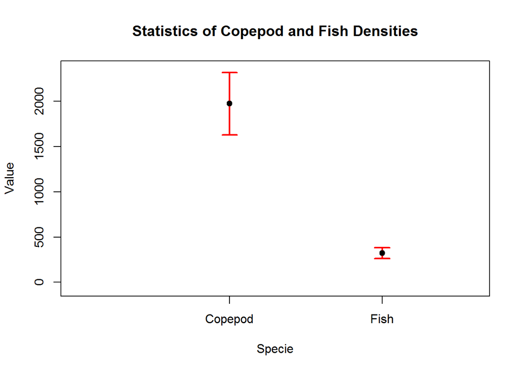

```r
# plot the statistics: mean and standard error of mean
PlotStat(
    c(cpod$Mean, fish$Mean),
    c(cpod$SE,   fish$SE))

# add plot information
axis(1, cex=2, at=c(1,2), labels=c("Copepod", "Fish"))
title(
    main="Statistics of Copepod and Fish Densities",
    xlab="Specie",
    ylab="Value")
```

### Histogram

plot the distribution of fish and copepod densities

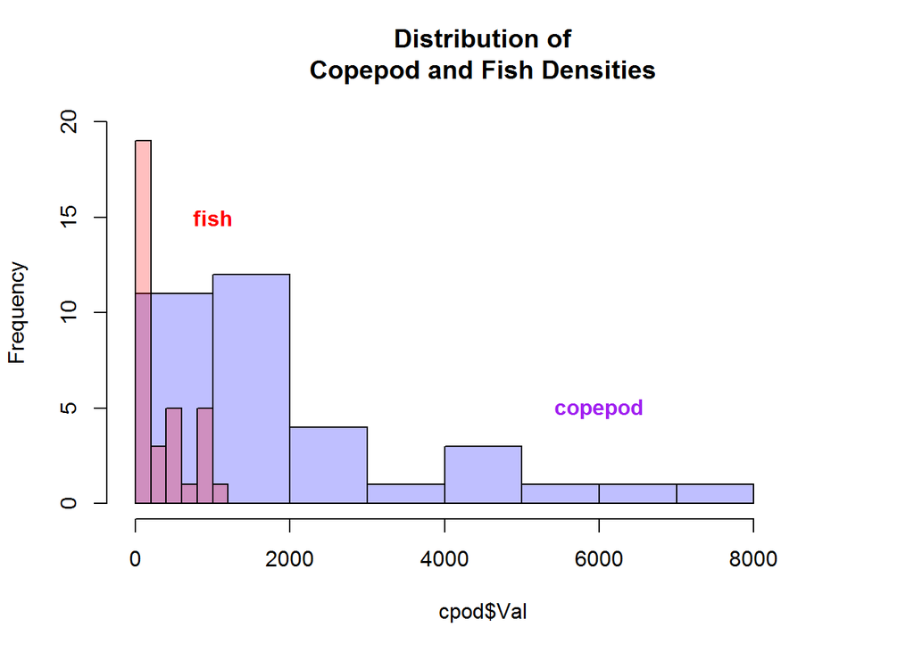

```r
# generate the histogram
gp1 <- hist(cpod$Val, plot=FALSE)
gp2 <- hist(fish$Val, plot=FALSE)

# visualize both histogram in one plot
#plot(gp1)
#plot(gp2)
plot(gp1, col=rgb(0,0,1,1/4),
     xlim=c(-10, 9000),
     ylim=c(  0, 20),
     main="Distribution of\nCopepod and Fish Densities")
plot(gp2, col=rgb(1,0,0,1/4), add=T)

# add text, indicating distribution of fish and copepod
text(x=6000, y=5,
     cex = 1.0, font = 2,
     col = "Purple",
     "copepod")
text(x=1000, y=15,
     cex = 1.0, font = 2,
     col = "Red",
     "fish")
```

# Create Function for Analysis

Function for probability distribution

```r
myUnif <- function(n, a=0, b=1) {
    # Continuous Uniform Distribution
    # Default: R.V. ~ Uniform( [0,1] )
    #====================================
    x <- runif(n)      # R.V. ~~~ Uniform( [0,1] )
    y <- x * (b-a) + a # Shift to Uniform( [a,b] )
    return(y)
} # end func myUnif
```

Function for Bootstrap

```r
mySample <- function(x){
    # The function is based on
    # return sample of x with replacement
    #===========================================
    # generate random numbers following uniform distribution
    n <- length(x)
    id <- myUnif(n, a=0, b=n)
    # convert continuous value into discrete
    id <- ceiling(id)
    # remove 0 (very rare case, p(X=0) is zero for any continuous random variable)
    id[id==0] <- 1

    # return the result
    return(x[id])
} # end mySample

myBootstrap <- function(avec=NULL, adat=NULL, f, N){
    # Perform bootstrap analysis
    #===========================================
    # Check if the input is vector or dataframe/matrix
    isVec <- !is.null(avec) # True if input a vector
    isDat <- !is.null(adat) # True if input a dataframe/matrix

    # Exception handling
    if ( isVec &  isDat) { stop("Too much input data") }
    if (!isVec & !isDat) { stop("No input data") }

    # if the input data is a vector
    if (isVec  & !isDat) {
        print("The input data is a vector...")
        # get id, the idx of vector
        id  <- seq_len(length(avec))
        # bootstrapping
        print("Performing bootstrapping...")
        val <- replicate(N,
            f(
                avec[mySample(id)]
            ) # end func
        ) # end replicate
    } # end if condition

    # if the input data is a dataframe/matrix
    if (!isVec & isDat) {
        print("The input data is a vector...")
        # get id, the idx of rows
        id  <- seq_len(nrow(adat))
        # bootstrapping
        print("Performing bootstrapping...")
        val <- replicate(N,
            f(
                adat[mySample(id),]
            ) # end func
        ) # end replicate
    } # end if condition

    # summary statistics & return the result
    print("...Finished")
    res <- list()
    res$Val <- val       # bootstrap pedvalue
    res$MU  <- mean(val) # mean of bootstrapped value
    res$SE  <- sd(val)   # standard error of mean
    return(res)
} # end func myBootstrap
```

helper function to visualize the bootstrap result; the aim of the function is listed as follow

- plot the histogram of bootstrapped value
- indicate the bootstrapped mean (color: blue)
- indicate the sample mean (color: red)

```r
PlotHist <- function(res, resBStrap, ...){
    # res: a number
    # resBStrap: a list
    ##############################
    hist(resBStrap$Val,
        col="grey90",
        xlim=c(range(resBStrap$Val)[1] * 0.7,
               range(resBStrap$Val)[2] * 1.3),
        ...)
    # add verticle lines
    abline(v=resBStrap$MU, lwd=5, col="steelblue1")
    abline(v=res,          lwd=2, col="red")
} # end func PlotHist
```

# 1. Compute the mean and SE(mean) for the fish and copepod densities

- Compute the mean and SE(mean) for the fish and copepod densities (assuming all data points are independent) respectively, using both normal theory and non-parametric bootstrap.
- Plot the histogram of bootstrapped means with bootstrap 1000 times. (Normal theory simply means using the standard formula to estimate SE.)

perform bootstrap analysis

```r
N <- 1000 # Iterations of bootstrapping

# Bootstrap of Fish Density Mean
bStrap_FishMean <- myBootstrap(avec=fish$Val, f=mean, N=N)
```

```
## [1] "The input data is a vector..."
## [1] "Performing bootstrapping..."
## [1] "...Finished"
```

```r
# Bootstrap of Copepod Density Mean
bStrap_CpodMean <- myBootstrap(avec=cpod$Val, f=mean, N=N)
```

```
## [1] "The input data is a vector..."
## [1] "Performing bootstrapping..."
## [1] "...Finished"
```

visualize the bootstrapped mean of fish density

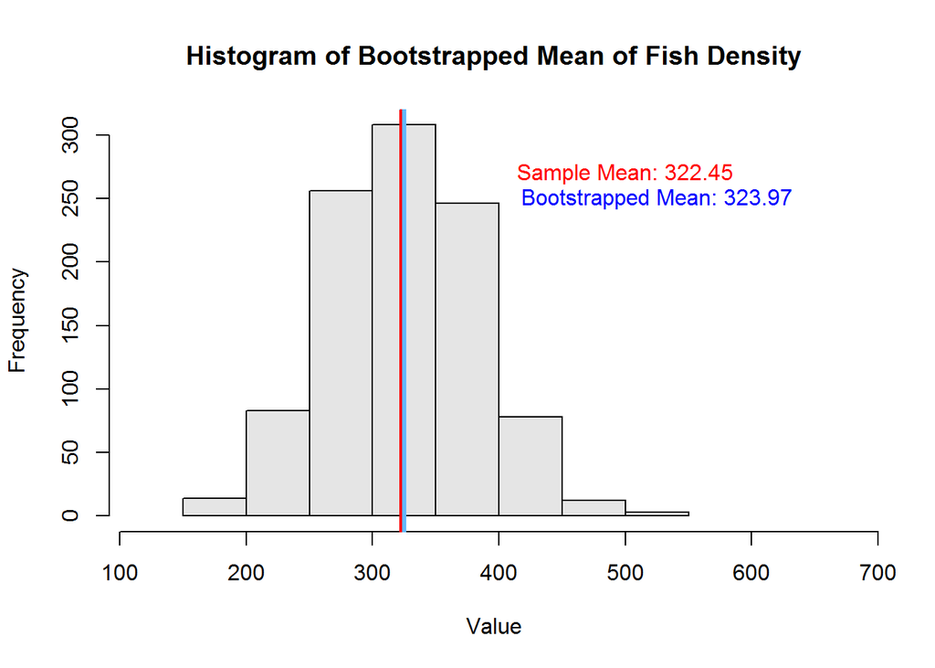

```r
PlotHist(fish$Mean, bStrap_FishMean,
    main="Histogram of Bootstrapped Mean of Fish Density",
    xlab="Value")

# add text
text(x=500,y=270, col="red",
    paste("Sample Mean:",
          signif(fish$Mean, 5)))
text(x=525,y=250, col="blue",
    paste("Bootstrapped Mean:",
          signif(bStrap_FishMean$MU, 5)))
```

visualize the bootstrapped mean of copepod density

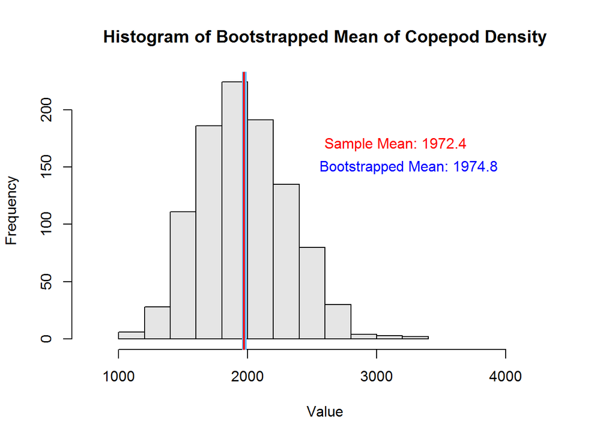

```r
PlotHist(cpod$Mean, bStrap_CpodMean,
    main="Histogram of Bootstrapped Mean of Copepod Density",
    xlab="Value")

# add text
text(x=3150,y=170, col="red",
    paste("Sample Mean:",
          signif(cpod$Mean, 5)))
text(x=3250,y=150, col="blue",
    paste("Bootstrapped Mean:",
          signif(bStrap_CpodMean$MU, 5)))
```

# 2. Compute the median and SE(median) for the fish and copepod densities

- Compute the median and SE(median) for the fish and copepod densities.
- Plot the histogram of bootstrapped medians with bootstrap 1000 times

perform bootstrap analysis

```r
N <- 1000 # Iterations of bootstrapping

# Bootstrap of Fish Density Mean
bStrap_FishMedian <- myBootstrap(avec=fish$Val, f=median, N=N)
```

```
## [1] "The input data is a vector..."
## [1] "Performing bootstrapping..."
## [1] "...Finished"
```

```r
# Bootstrap of Copepod Density Mean
bStrap_CpodMedian <- myBootstrap(avec=cpod$Val, f=median, N=N)
```

```
## [1] "The input data is a vector..."
## [1] "Performing bootstrapping..."
## [1] "...Finished"
```

visualize the bootstrapped median of fish density

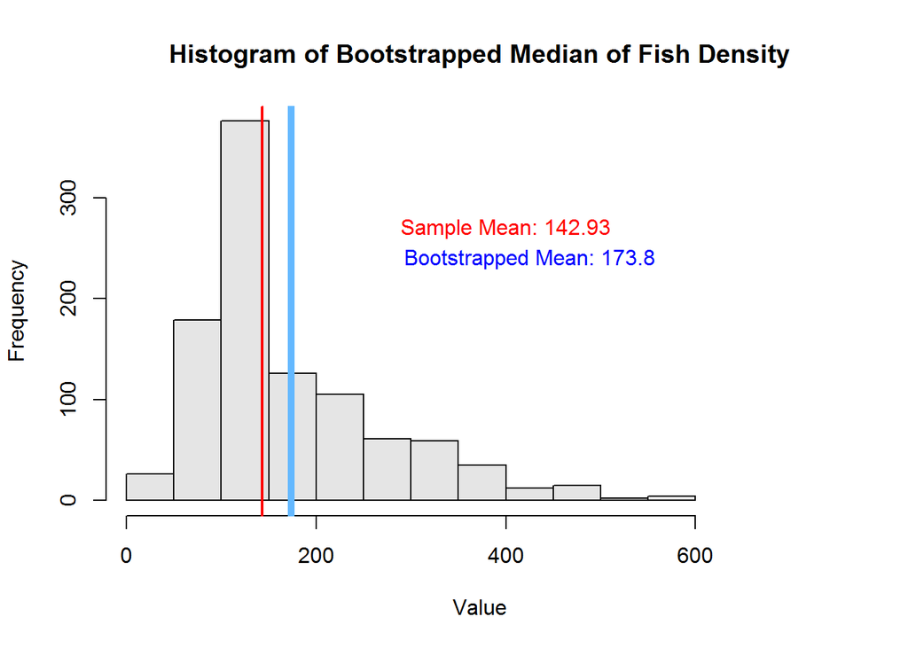

```r
PlotHist(fish$Median, bStrap_FishMedian,
    main="Histogram of Bootstrapped Median of Fish Density",
    xlab="Value")

# add text
text(x=400,y=270, col="red",
    paste("Sample Mean:",
          signif(fish$Median, 5)))
text(x=425,y=240, col="blue",
    paste("Bootstrapped Mean:",
          signif(bStrap_FishMedian$MU, 5)))
```

visualize the bootstrapped median of copepod density

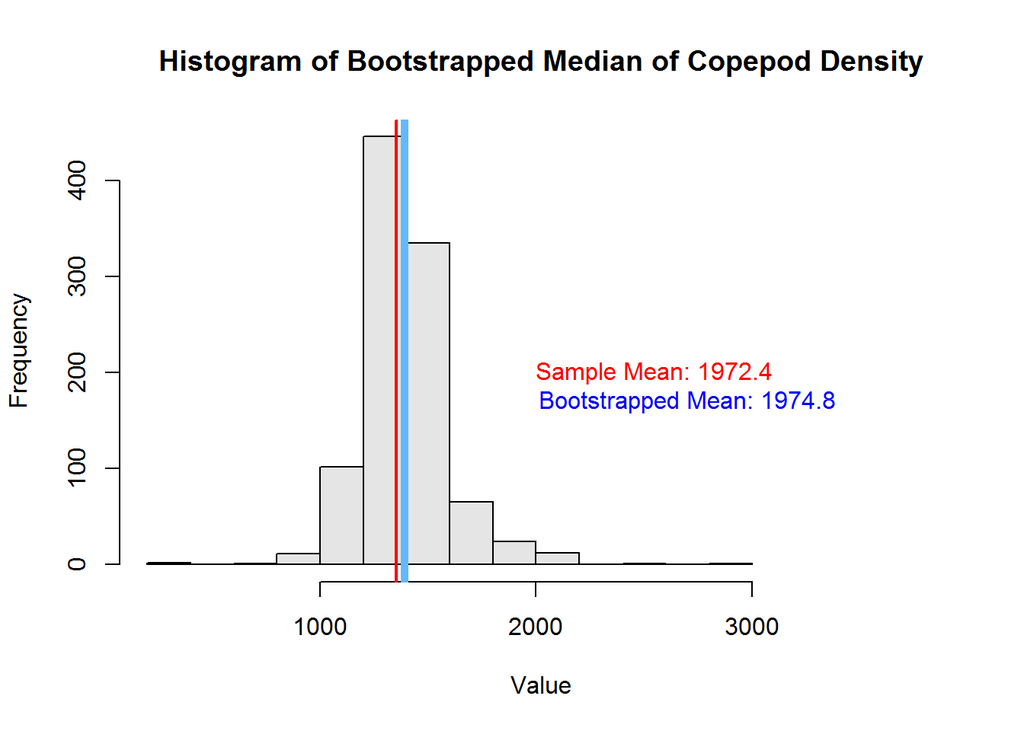

```r
PlotHist(cpod$Median, bStrap_CpodMedian,
    main="Histogram of Bootstrapped Median of Copepod Density",
    xlab="Value")

# add text
text(x=2550,y=200, col="red",
    paste("Sample Mean:",
          signif(cpod$Mean, 5)))
text(x=2700,y=170, col="blue",
    paste("Bootstrapped Mean:",
          signif(bStrap_CpodMean$MU, 5)))
```

# Compare the Bootstrapped estimators and the sample estimators

Compare the Sample and Bootstrapped Means, including the standard errors respectively; as you can see, there is not much difference between sample and bootstrapped means

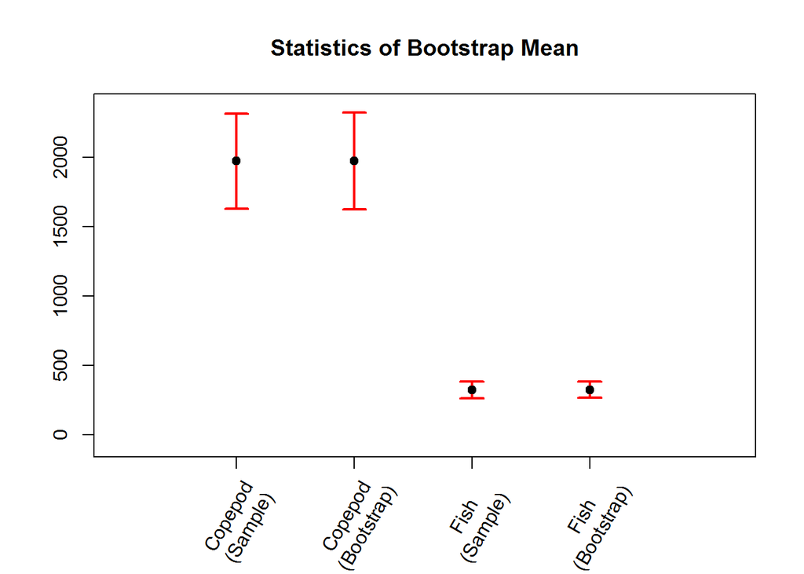

```r
# plot summary statistics of bootstraped mean
PlotStat(
    c(cpod$Mean,   bStrap_CpodMean$MU,
      fish$Mean,   bStrap_FishMean$MU),
    c(cpod$SE,     bStrap_CpodMean$SE,
      fish$SE,     bStrap_FishMean$SE))

# add labels
title(main="Statistics of Bootstrap Mean")
axis(1, at=c(1,2,3,4), labels=FALSE)
text(c(1,2,3,4)-0.1, par("usr")[3] - 330,
     labels = c(
         "Copepod\n(Sample)", "Copepod\n(Bootstrap)",
         "Fish\n(Sample)", "Fish\n(Bootstrap)"),
     cex = 1.0,
     srt = 60,
     pos = 1,
     xpd = TRUE)
```

Compare the Sample and Bootstrapped Median; note that the sample median is pointed beside the bootstrapped median

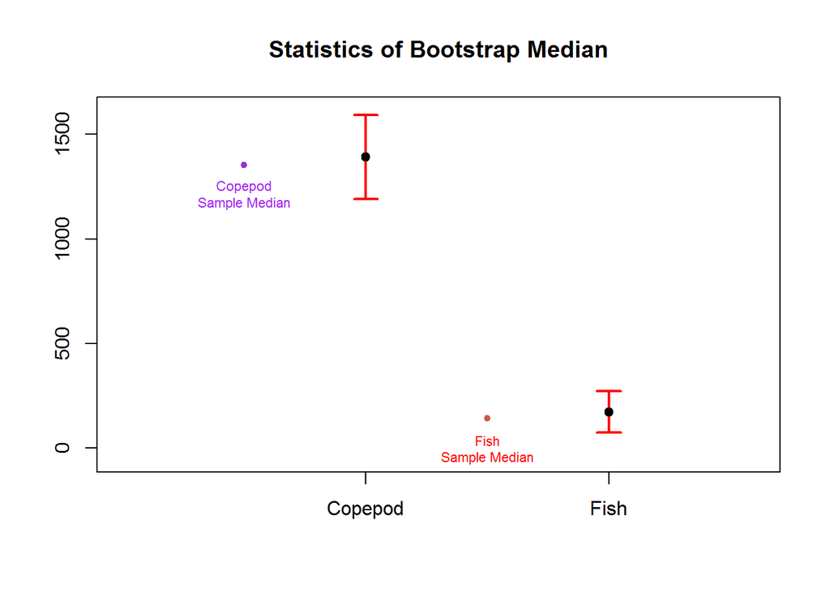

```r
# plot summary statistics of bootstraped median
PlotStat(
    c(bStrap_CpodMedian$MU,
      bStrap_FishMedian$MU),
    c(bStrap_CpodMedian$SE,
      bStrap_FishMedian$SE))

# Add sample median
points(x=0.5, y=cpod$Median, pch=20, col="#9932cc")
text(  x=0.5, y=cpod$Median * 0.9,
       cex=0.7, col="Purple",
       "Copepod\nSample Median")

points(x=1.5, y=fish$Median, pch=20, col="#cd5b45")
text(  x=1.5, y=0,
       cex=0.7, col="Red",
       "Fish\nSample Median")

# add labels
title(main="Statistics of Bootstrap Median")
axis(1, at=c(1,2), labels=c("Copepod", "Fish"))
```

# 3. Linear Regression

encapsulate the calculation of regression coefficients

```r
# encapsulate the function
myFunc <- function(dat){
    # the function input a data.frame, which contains two column X and Y
    # perform the linear regression and acquire the coefficients
    res <- RegBeta(x=dat$X, y=dat$Y)
    return(as.vector(res))
} # end myFunc

# encapsulate the data
dat <- data.frame(
    X=cpod$Val,
    Y=fish$Val)

# test function
#tmp <- myFunc(dat)
#print(tmp)
#print(beta)
```

```r
# boostrapping
N <- 1000
tmp <- myBootstrap(adat=dat, f=myFunc, N=N)
```

```
## [1] "The input data is a vector..."
## [1] "Performing bootstrapping..."
## [1] "...Finished"
```

```r
# store the results: beta0
res <- list()
res$Val <- tmp$Val[1,]
res$MU  <- mean(res$Val)
res$SE  <- sd(res$Val)
bStrap_Beta0 <- res

# store the results: beta1
res <- list()
res$Val <- tmp$Val[2,]
res$MU  <- mean(res$Val)
res$SE  <- sd(res$Val)
bStrap_Beta1 <- res
```

visualize the bootstrapped regression coefficients

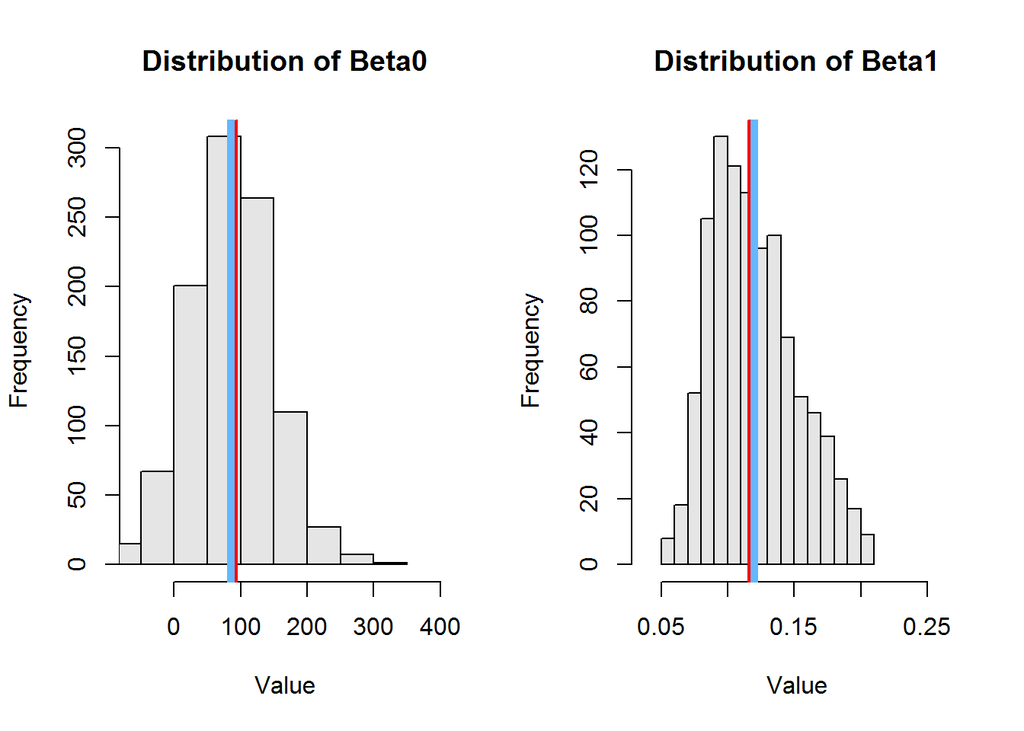

```r
par(mfrow=c(1,2))

PlotHist(beta$b0, bStrap_Beta0,
    main="Distribution of Beta0",
    xlab="Value")

PlotHist(beta$b1, bStrap_Beta1,
    main="Distribution of Beta1",
    xlab="Value")
```